# Modèles VAR & VECM

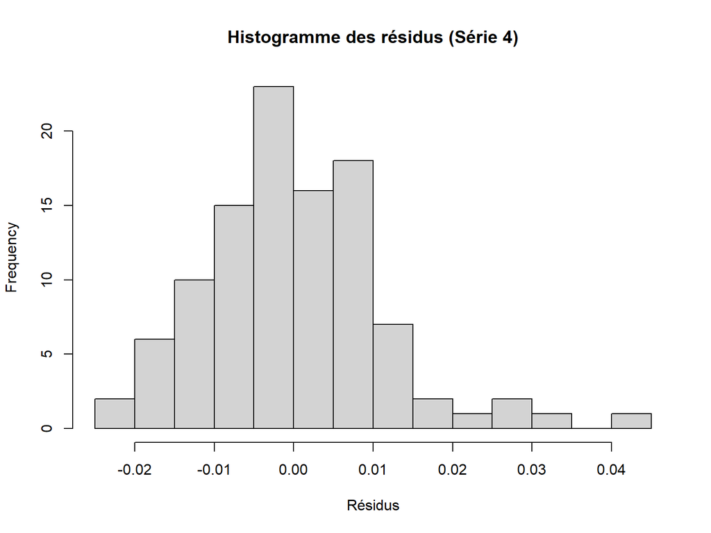

```r
hist(residuals[, 4], main = "Histogramme des résidus (Série 4)", xlab = "Résidus", breaks = 20)
```

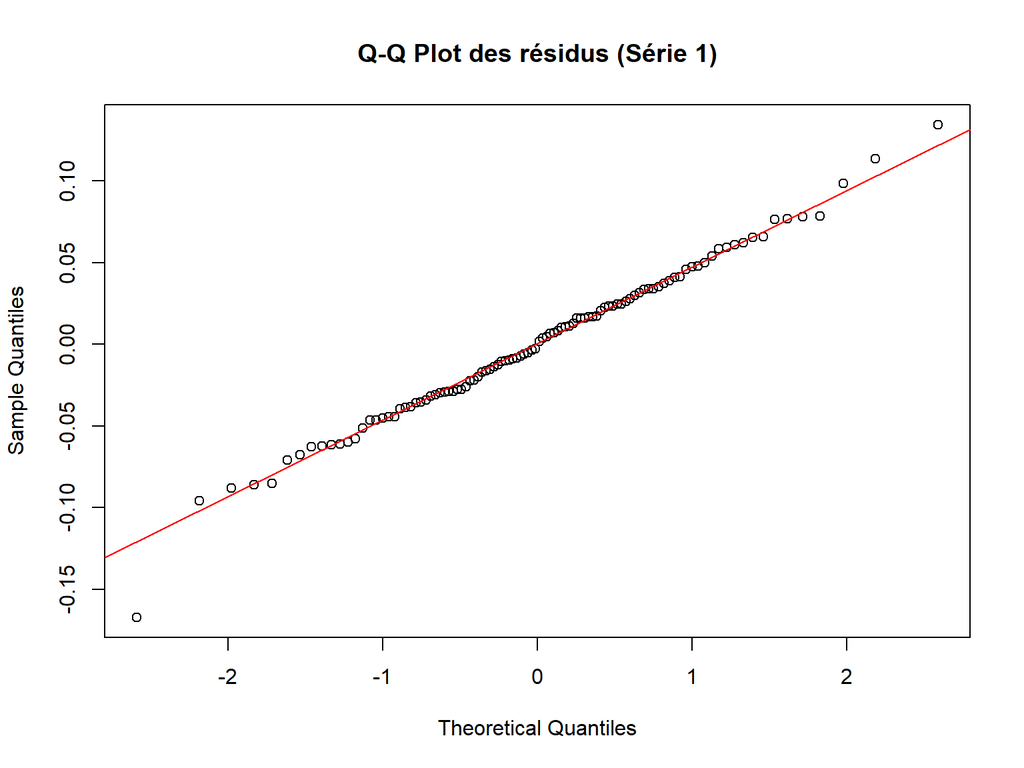

```r
# Q-Q Plot des résidus
qqnorm(residuals[, 1], main = "Q-Q Plot des résidus (Série 1)")
qqline(residuals[, 1], col = "red")
```

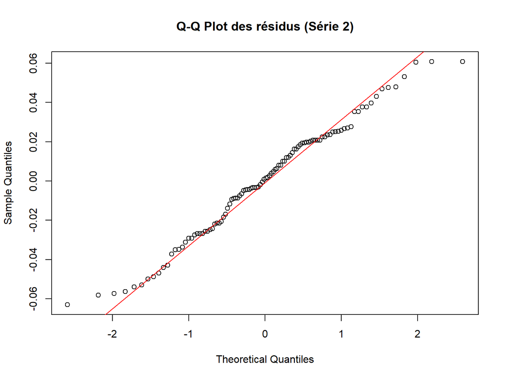

```r
qqnorm(residuals[, 2], main = "Q-Q Plot des résidus (Série 2)")
qqline(residuals[, 2], col = "red")
```

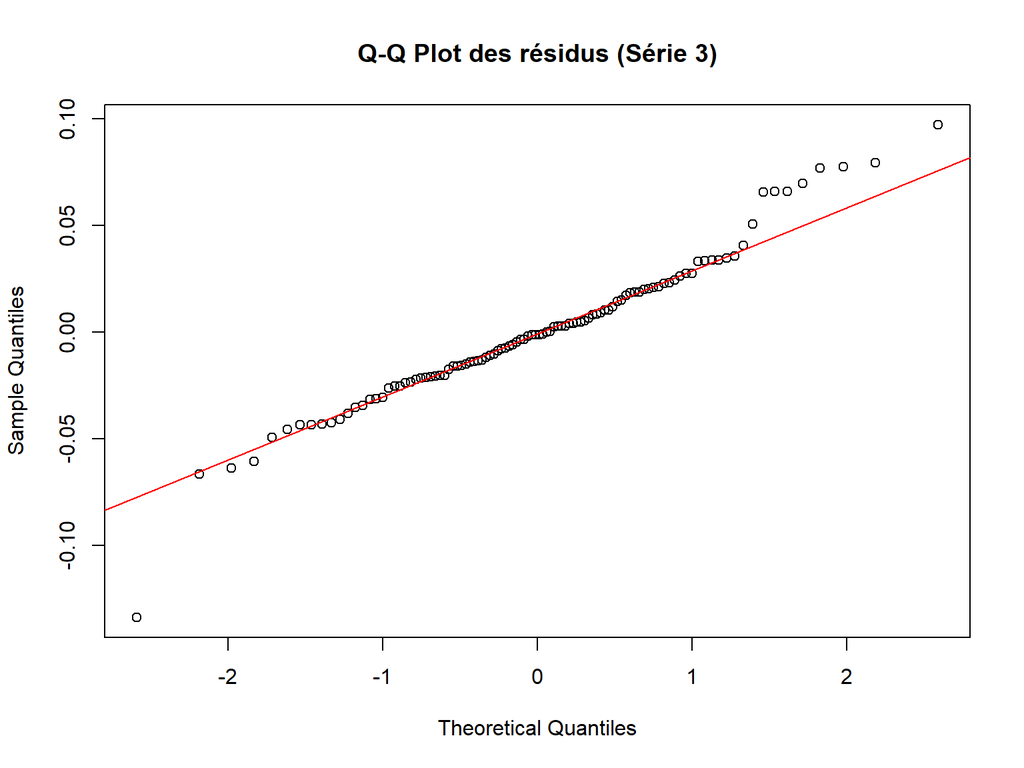

```r
qqnorm(residuals[, 3], main = "Q-Q Plot des résidus (Série 3)")
qqline(residuals[, 3], col = "red")
```

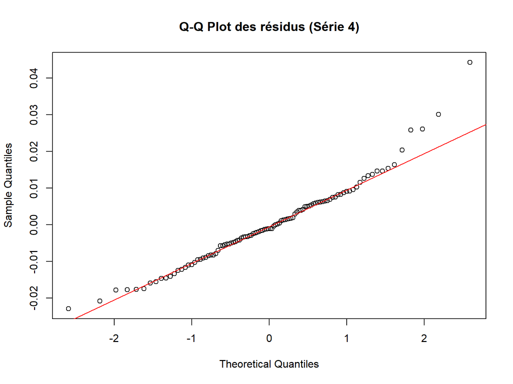

```r
qqnorm(residuals[, 4], main = "Q-Q Plot des résidus (Série 4)")
qqline(residuals[, 4], col = "red")
```

```r
# Jacques Bera test
library(tseries)
 jarque.bera.test(residuals[, 1])
```

```
##
##  Jarque Bera Test
##
## data:  residuals[, 1]
## X-squared = 2.1364, df = 2, p-value = 0.3436
```

```r
jarque.bera.test(residuals[, 2])
```

```
##
##  Jarque Bera Test
##
## data:  residuals[, 2]
## X-squared = 1.6874, df = 2, p-value = 0.4301
```

```r
jarque.bera.test(residuals[, 3])
```

```
##
##  Jarque Bera Test
##
## data:  residuals[, 3]
## X-squared = 13.94, df = 2, p-value = 0.0009395
```

```r
jarque.bera.test(residuals[, 4])
```

```
##
##  Jarque Bera Test
##
## data:  residuals[, 4]
## X-squared = 24.569, df = 2, p-value = 4.623e-06
```

Le test montre qu’il y a normalité sur les résidus des séries 1 et 2 (lrm1 et lny) mais pas pour les deux dernières séries.

# Points clés à retenir

Les séries chronologiques pour les données économiques sont généralement stochastiques ou ont une tendance qui n’est pas stationnaire, ce qui signifie que les données ont une unité racine. Pour pouvoir estimer un modèle en utilisant les données :

Étapes pour VAR :

- Tester la stationnarité des données et le degré d’intégration
- Détermination de la longueur du retard
- Tester la causalité de Granger
- Estimation du VAR
- Décomposition de la variance

Étapes pour VECM :

- Détermination de la longueur du retard
- Tester la causalité de Granger
- Test de degré de cointégration
- Estimation de VECM
- Décomposition de la variance

# Références

- Database from Kaggle : https://www.kaggle.com/datasets/faseeh001/commoditiesinvestingcom
- https://www.r-bloggers.com/2021/12/vector-error-correction-model-vecm-using-r/